# Project1

Unknown

10/27/2019

## Задание №1

### Пользовательская функция для объединения всех файлов из заданной папки.

Перед запуском проверяем текущую папку (в адресе должно быть указание папки, в которой лежат данные. Также проверяем, что в такой папке лежат только необходимые данные с расширением csv.

```
## [1] "/home/dasmez/Desktop/bioinf/R statistics/Data"
```

Пользовательская функция по объединению всех файлов будет иметь следующий вид:

```r
all_files <- function(files, dataset){
  len <- length(files)
  dataset <- read.csv(files[1])
  for (i in 2:len){
    a <- read.csv(files[i])
    dataset <- rbind(dataset, a)
  }
write.csv(dataset, "../merged_files.csv")
}

all_files(files, dataset) #Указываем имя для входного переменной со списком всех данных и имя для новой переменной, в которую будут объединены все данные
```

Проверяем получившийся файл и число объектов. Радуемся.

```
## 'data.frame':    4177 obs. of  10 variables:
##  $ X                                     : int  1 2 3 4 5 6 7 8 9 10 ...
##  $ Rings                                 : Factor w/ 29 levels "1","10","11",..: 10 6 27 4 23 23 4 27 25 27 ...
##  $ Sex..1...male..2...female..3...uvenil.: Factor w/ 6 levels "1","2","3","male",..: 2 3 1 1 3 3 1 2 3 2 ...
##  $ Length                                : Factor w/ 135 levels "0.075","0.11",..: 91 53 71 109 32 20 120 86 23 56 ...
##  $ Diameter                              : num  0.45 0.305 0.37 0.525 0.12 0.16 0.565 0.43 0.175 0.3 ...
##  $ Height                                : num  0.17 0.095 0.125 0.18 0.075 0.05 0.2 0.15 0.055 0.115 ...
##  $ Whole_weight                          : num  1.048 0.252 0.649 1.429 0.117 ...
##  $ Shucked_weight                        : num  0.3775 0.0915 0.347 0.6715 0.0455 ...
##  $ Viscera_weight                        : num  0.171 0.055 0.136 0.29 0.029 ...
##  $ Shell_weight                          : num  0.385 0.09 0.142 0.4 0.0345 0.015 0.494 0.221 0.018 0.0935 ...
```

## Задание №2

### Проверка корректности данных.

По структуре данных видно, что переменные Rings, Length и Sex… имеют тип “Factor”:

```
## 'data.frame':    4177 obs. of  10 variables:
##  $ X                                     : int  1 2 3 4 5 6 7 8 9 10 ...
##  $ Rings                                 : Factor w/ 29 levels "1","10","11",..: 10 6 27 4 23 23 4 27 25 27 ...
##  $ Sex..1...male..2...female..3...uvenil.: Factor w/ 6 levels "1","2","3","male",..: 2 3 1 1 3 3 1 2 3 2 ...
##  $ Length                                : Factor w/ 135 levels "0.075","0.11",..: 91 53 71 109 32 20 120 86 23 56 ...
##  $ Diameter                              : num  0.45 0.305 0.37 0.525 0.12 0.16 0.565 0.43 0.175 0.3 ...
##  $ Height                                : num  0.17 0.095 0.125 0.18 0.075 0.05 0.2 0.15 0.055 0.115 ...
##  $ Whole_weight                          : num  1.048 0.252 0.649 1.429 0.117 ...
##  $ Shucked_weight                        : num  0.3775 0.0915 0.347 0.6715 0.0455 ...
##  $ Viscera_weight                        : num  0.171 0.055 0.136 0.29 0.029 ...
##  $ Shell_weight                          : num  0.385 0.09 0.142 0.4 0.0345 0.015 0.494 0.221 0.018 0.0935 ...
```

Вывод всех уровней переменной Rings показал, что единственный параметр, требующий замены - “nine”:

```
##  [1] "1"    "10"   "11"   "12"   "13"   "14"   "15"   "16"   "17"   "18"
## [11] "19"   "2"    "20"   "21"   "22"   "23"   "24"   "25"   "26"   "27"
## [21] "29"   "3"    "4"    "5"    "6"    "7"    "8"    "9"    "nine"
```

Вывод всех уровней переменной Length показал, что нет таких числовых параметров, которые были записаны в буквенном виде, поэтому можно сразу перевести всё в числовой формат без дополнительных изменений:

```
##   [1] "0.075"                            "0.11"
##   [3] "0.13"                             "0.135"
##   [5] "0.14"                             "0.15"
##   [7] "0.155"                            "0.16"
##   [9] "0.165"                            "0.17"
##  [11] "0.175"                            "0.18"
##  [13] "0.185"                            "0.19"
##  [15] "0.195"                            "0.2"
##  [17] "0.205"                            "0.21"
##  [19] "0.215"                            "0.22"
##  [21] "0.225"                            "0.23"
##  [23] "0.235"                            "0.24"
##  [25] "0.245"                            "0.25"
##  [27] "0.255"                            "0.26"
##  [29] "0.265"                            "0.27"
```

[output cut: 53 more lines]

Вывод всех уровней переменной пола показал, что некоторые измерения, которые должны быть числовыми, записаны словами:

```
## [1] "1"     "2"     "3"     "male"  "one"   "three"
```

После преобразования переменных видно, что все числовые параметры записаны как числа:

```
## 'data.frame':    4177 obs. of  10 variables:
##  $ X                                     : int  1 2 3 4 5 6 7 8 9 10 ...
##  $ Rings                                 : num  18 14 8 12 4 4 12 8 6 8 ...
##  $ Sex..1...male..2...female..3...uvenil.: num  2 3 1 1 3 3 1 2 3 2 ...
##  $ Length                                : num  0.575 0.385 0.475 0.665 0.28 0.22 0.72 0.55 0.235 0.4 ...
##  $ Diameter                              : num  0.45 0.305 0.37 0.525 0.12 0.16 0.565 0.43 0.175 0.3 ...
##  $ Height                                : num  0.17 0.095 0.125 0.18 0.075 0.05 0.2 0.15 0.055 0.115 ...
##  $ Whole_weight                          : num  1.048 0.252 0.649 1.429 0.117 ...
##  $ Shucked_weight                        : num  0.3775 0.0915 0.347 0.6715 0.0455 ...
##  $ Viscera_weight                        : num  0.171 0.055 0.136 0.29 0.029 ...
##  $ Shell_weight                          : num  0.385 0.09 0.142 0.4 0.0345 0.015 0.494 0.221 0.018 0.0935 ...
```

Проверка на наличие NA данных в столбцах выявила некоторые из них. В столбце с определением пола есть NA значение - можно удалить, поскольку такое значение не восстановить по другим (и потеря одного измерения из 4177 не будет критичной). Остальные NA заменили на все самые частые значения по переменной, в которой находится NA, чтобы минимизировать их вклад (хотя пропущенных данных не очень много - 22 значения на весь датафрейм, и любая замена ничего серьёзного не внесет):

```
## [1] "столбцы с NA"
## [1] 3
## [1] "столбцы с NA"
## [1] 4
## [1] "столбцы с NA"
## [1] 5
## [1] "столбцы с NA"
## [1] 6
## [1] "столбцы с NA"
## [1] 7
## [1] "столбцы с NA"
## [1] 8
## [1] "столбцы с NA"
## [1] 10
```

## Задание №3

### Среднее значение и стандартное отклонение переменной Length для моллюсков разного пола.

Вычисление значений среднего и стандартное отклонение переменной Length для моллюсков разного пола привело к следующим результатам:

```
##        sex      mean         sd
## 1   female 0.5790965 0.08617493
## 2     male 0.5615412 0.10254264
## 3 juvenile 0.4279508 0.10894883
```

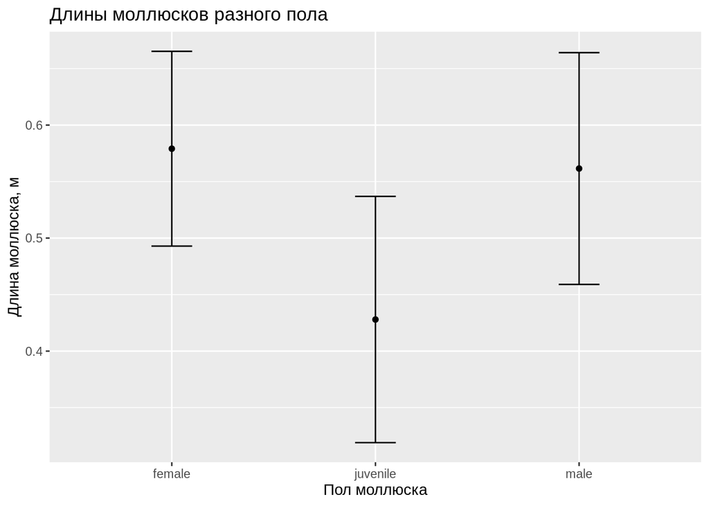

### Вывод:

*По значениям из таблицы, а также по графику для средних значений и стандартных отклонений длин моллюсков в зависимости от их пола видно, что пол не влияет на различия между женскими и мужскими особями. Для молодых особей наблюдается некоторое снижение, что может объясняться их возрастом и неоконченной стадией роста.*

## Задание №4

### Определение процента моллюсков, у которых значение переменной Height не превышает 0.165

Для определения процента моллюсков, подходящих под условие было необходимо сначала отобрать всех особей, параметр Height которых не превышает 0.165 и затем разделить полученное число на общее число наблюдений.

Вычисленное значение будет равно 75.89%.

Построение распределения высот моллюсков в выборке визуально подтвердило правильность полученных результатов:

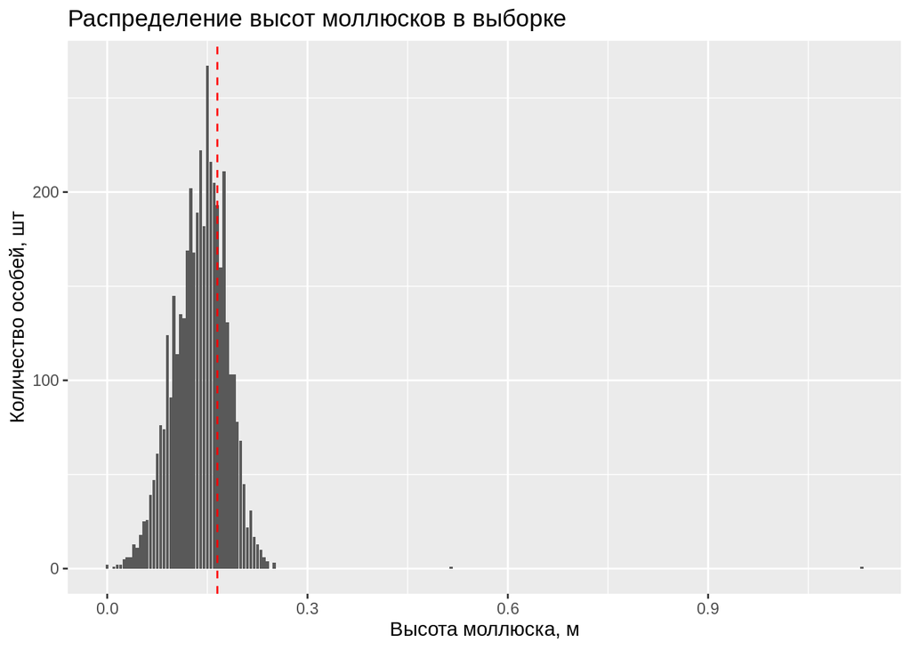

### Вывод:

*Значение переменной Height для 75.89% моллюсков не превышает 0.165.*

## Задание №5

### Определение значения переменной Length, которое выше чем 92% от всех наблюдений

Визуализация результатов:

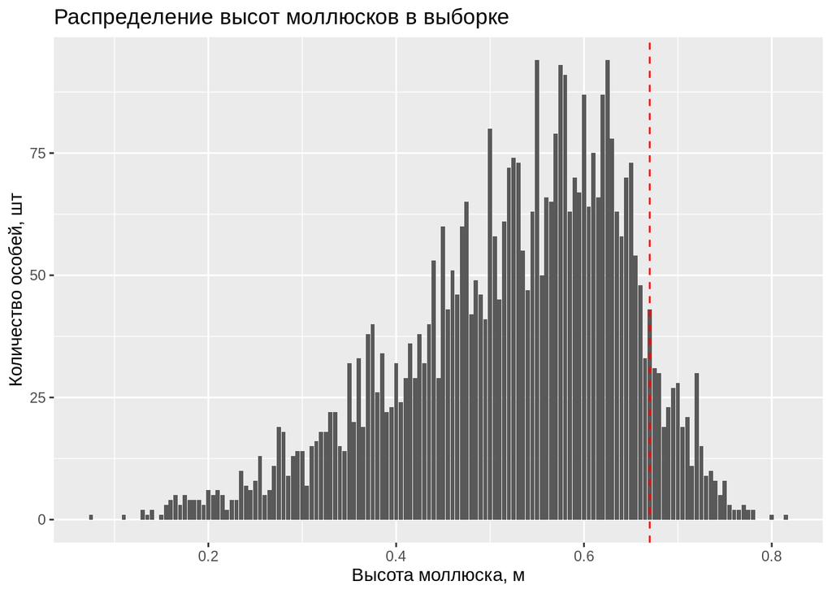

### Вывод:

*Для 92% моллюсков значение переменной Length не превышает 0.67.*

## Задание №6

### Стандартизация переменной Length и сохранение полученных данных в новую переменную Lenght_z_scores

Проведение стандартизации и добавления новой переменной были проведены и проверены с помощью apply, а также с помощью вывода нового датасета. Новая переменная добавлена (проверка всех переменных):

```
## 'data.frame':    4176 obs. of  11 variables:
##  $ X                                     : num  1 2 3 4 5 6 7 8 9 10 ...
##  $ Rings                                 : num  18 14 8 12 4 4 12 8 6 8 ...
##  $ Sex..1...male..2...female..3...uvenil.: num  2 3 1 1 3 3 1 2 3 2 ...
##  $ Length                                : num  0.575 0.385 0.475 0.665 0.28 0.22 0.72 0.55 0.235 0.4 ...
##  $ Diameter                              : num  0.45 0.305 0.37 0.525 0.12 0.16 0.565 0.43 0.175 0.3 ...
##  $ Height                                : num  0.17 0.095 0.125 0.18 0.075 0.05 0.2 0.15 0.055 0.115 ...
##  $ Whole_weight                          : num  1.048 0.252 0.649 1.429 0.117 ...
##  $ Shucked_weight                        : num  0.3775 0.0915 0.347 0.6715 0.0455 ...
##  $ Viscera_weight                        : num  0.171 0.055 0.136 0.29 0.029 ...
##  $ Shell_weight                          : num  0.385 0.09 0.142 0.4 0.0345 0.015 0.494 0.221 0.018 0.0935 ...
##  $ Length_z_scores                       : num [1:4176, 1] 0.424 -1.159 -0.409 1.174 -2.033 ...
##   ..- attr(*, "scaled:center")= num 0.524
##   ..- attr(*, "scaled:scale")= num 0.12
```

Проверяем sd переменной после стандартизации:

```
## Length_z_scores
##               1
```

Проверяем mean переменной после стандартизации:

```
## Length_z_scores
##   -3.807332e-18
```

По графикам до и после стандартизации переменной Length видно, что вид распределения не изменился, однако, произошли изменения шкалы результатов.

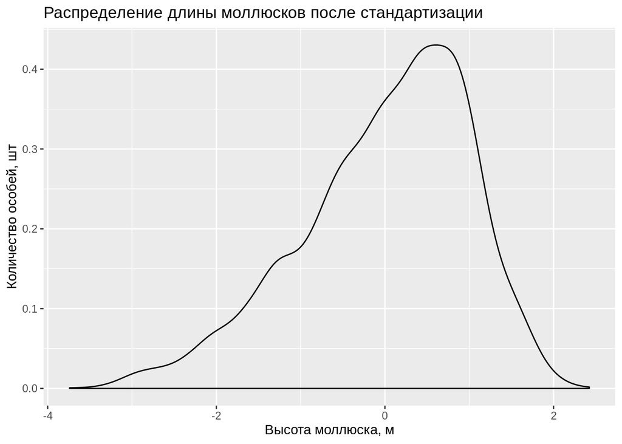

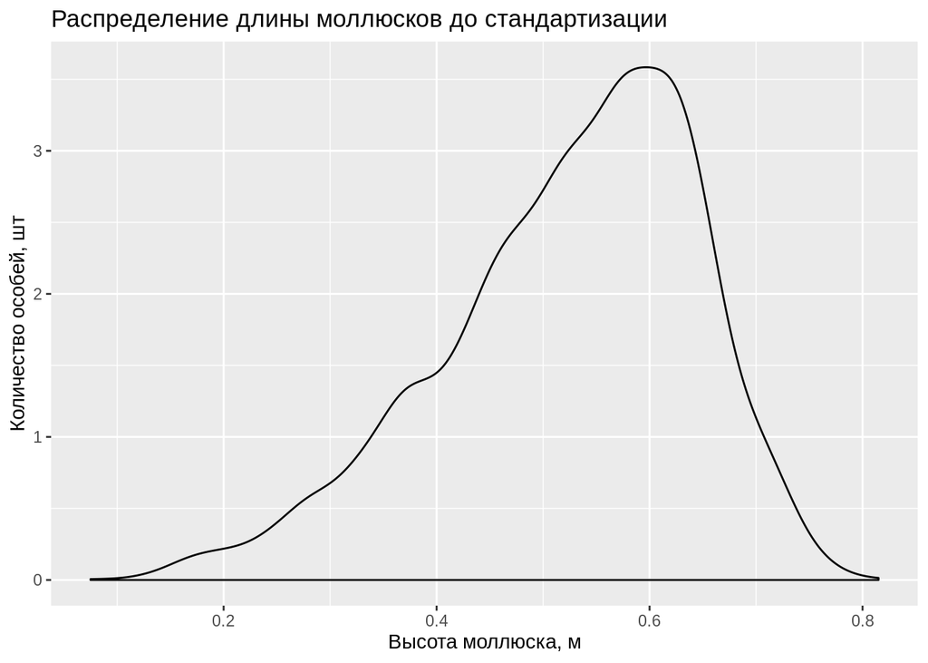

### Вывод: *После проведения стандартизации изменилась только шкала данных, но не распределение данных - всё прошло по плану.*

## Задание №7

### Сравнение диаметров моллюсков с числом колец 5 и 15

[figure not shown]

Сформулируем гипотезу H0 для обоих распределений: пусть каждое из распределений не отличается от нормального.

## Задание №8

### Корреляционная взаимосвязь переменных Diametr и Whole_weight

*Вычисление значения корреляции для переменных Diametr и Whole_weight показало, что параметр корреляции близок к 1 (* 0.9704621 *), при p < 2.2e-16, то есть можно сказать, что наблюдается положительная корреляция между весом и диаметром моллюска. То есть с увеличением одного параметра, увеличивается и другой:*

```
##       rho
## 0.9704621
```

*Построение зависимости веса от диаметра моллюска выявили exp рост веса при увеличении диаметра:*

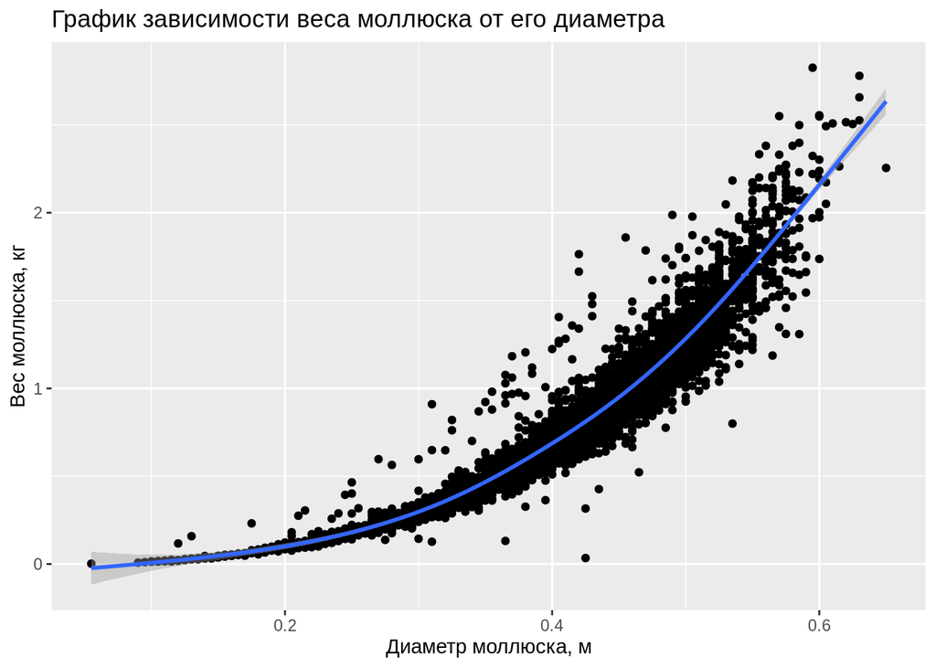

*Построение зависимости веса от диаметра моллюска для каждого пола не выявило значительных отличий темпов роста между собой exp рост веса при увеличении диаметра.*

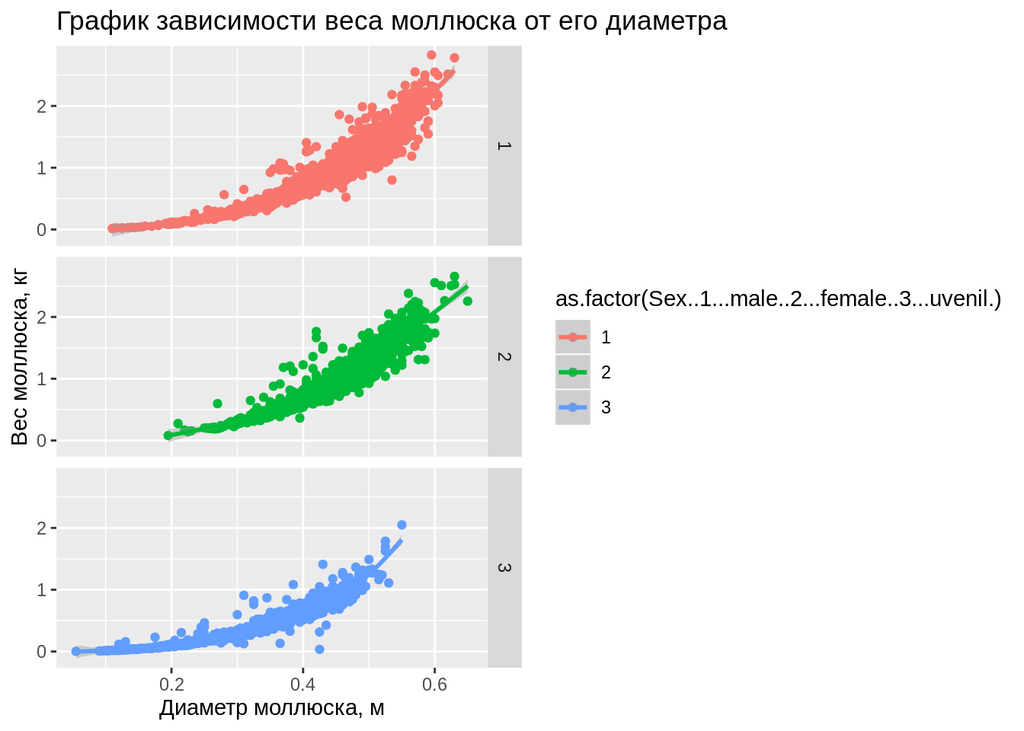